# How the scenario responses scale with the substitution share ρ

The reported responses are proportional to ρ to within a few per cent, and the sign-pattern regimes do not depend on it. The contained-contraction regime does: it is a threshold label, and as ρ rises most contained partner responses cross the threshold at a ρ this report gives run by run.

Author

Oriol Vallès Codina — LEEDS_MODEL / JUST2CE

Published

October 22, 2026

**Written:** 2026-10-22 · **Repo at:** `main` @ 43875f4

**Read from:** `output/sensitivity/rho_20261022/{responses_long,rho_fits,rho_labels}.csv`, written by `R/scenarios/rho_linearity.R` from 120 stored runs (the arm caches at ρ = 0.2 and the re-made runs at the other values, `output/sensitivity/rho_20261022/rho_*/`, by `run_rho.sh`). Every number below is computed in this document from those three files.

**Status of claims:** measured. The cause of the ρ = 1 failures is inferred, not traced, and is marked as such.

## What was run

Every intervention moves a share ρ of the primary sector’s demand to its substitute (Scenario design, §4.1); the paper reports ρ = 0.2. The question is whether the reported responses — and the cross-border regimes built on them — depend on that choice. The 24 gold-closure high-finance credit runs (twelve interventions × the EU/RoW and North/South setups) were re-made at ρ = 0.1, 0.4 and 0.7, and at ρ = 1.0 for the eight production interventions and 0.9 for the four final-demand ones.

**Why 0.9 for the final-demand interventions.** At ρ = 1.0 all eight final-demand runs (sc1–sc4, both setups) stop at t = 70, the shock period, on the first iteration, with an NA in the credit-rationing step (`model/code/MVP_model_2026.R:1026`). At ρ = 1 the primary sector’s whole share in that channel moves, so a share reaches exactly zero; a 0/0 there is the likely cause (inferred, not traced). ρ = 1 is a corner of the operator, not a policy anyone proposes, so the engine was not changed. All eight run at ρ = 0.9.

The response is the one the paper reports: the mean over t = 79…100 of the percentage deviation from the run’s own baseline (the current account as a level difference, since it crosses zero).

## Responses are proportional to ρ

Each run and variable is fitted through the origin (ρ = 0 is the baseline) in two ways: the line y = bρ, whose uncentred R² is 1 when the response is exactly proportional, and the quadratic y = β₁ρ + β₂ρ², whose ratio β₂/β₁ is the relative departure from proportionality at ρ = 1.

Linearity in ρ over the 24 runs, by variable and region.

| Variable | Region | R² median | R² lowest | \|β₂/β₁\| median |
| --- | --- | --- | --- | --- |
| Value added | Z1 (EU / North) | 1.0000 | 0.996 | 0.018 |
| Value added | Z2 (RoW / South) | 0.9997 | 0.950 | 0.041 |
| Consumption | Z1 (EU / North) | 0.9999 | 0.958 | 0.037 |
| Consumption | Z2 (RoW / South) | 0.9998 | 0.963 | 0.029 |
| Material throughput | Z1 (EU / North) | 1.0000 | 0.999 | 0.004 |
| Material throughput | Z2 (RoW / South) | 0.9997 | 0.972 | 0.053 |
| CO2 emissions | Z1 (EU / North) | 1.0000 | 0.981 | 0.013 |
| CO2 emissions | Z2 (RoW / South) | 0.9997 | 0.995 | 0.037 |
| Disposable income | Z1 (EU / North) | 1.0000 | 0.955 | 0.020 |
| Disposable income | Z2 (RoW / South) | 0.9997 | 0.953 | 0.052 |
| Current account | Z1 (EU / North) | 0.9996 | 0.938 | 0.075 |
| Current account | Z2 (RoW / South) | 0.9996 | 0.938 | 0.075 |

The median R² is above 0.999 for every variable and region. The largest curvature ratios (8 fits with |β₂/β₁| > 1, up to 5.7) belong to runs whose response is close to zero: the median |response at ρ = 0.2| of those fits is 0.0006, so β₁ is small and the ratio is not a measure of nonlinearity.

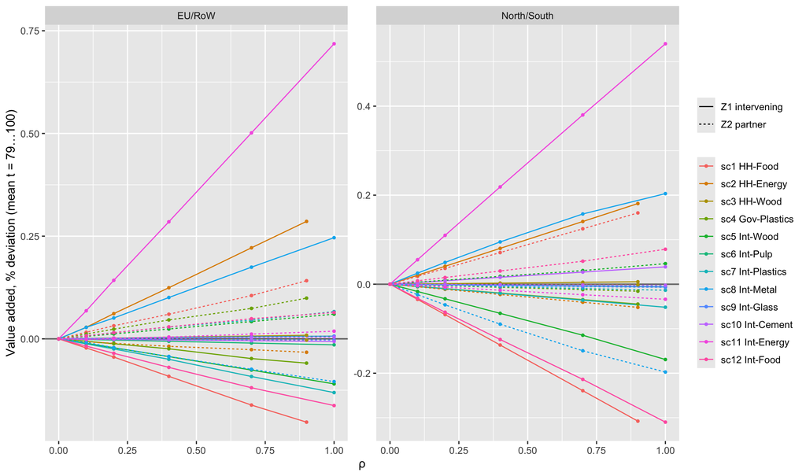

Figure 1: Value-added response against ρ, every run. Solid: intervening region (Z1); dashed: partner (Z2). The grey band is ±τ = 0.003%, the threshold below which a partner response counts as contained.

## The regimes

The cross-border regime of a run is read from the signs of the two regions’ value-added responses: production leakage (PL: the intervening region contracts, the partner expands), competitive displacement (CD: the reverse), dual contraction (DC), dual expansion (DE), and contained contraction (CC: the partner’s |response| is below τ = 0.003%).

Regime of every run at every ρ. — : not run (0.9 for the production interventions, 1.0 for the final-demand ones). Last column: for runs contained at the reported ρ = 0.2, the ρ at which the partner’s value-added response first reaches τ (linear interpolation between grid points).

| Setup | Scenario | ρ = 0.1 | ρ = 0.2 | ρ = 0.4 | ρ = 0.7 | ρ = 0.9 | ρ = 1.0 | ρ at which \|partner\| reaches τ |
| --- | --- | --- | --- | --- | --- | --- | --- | --- |
| EU/RoW | sc1 HH-Food | PL | PL | PL | PL | PL | — |  |
| EU/RoW | sc2 HH-Energy | CD | CD | CD | CD | CD | — |  |
| EU/RoW | sc3 HH-Wood | CC | CC | CC | CC | CD | — | 0.89 |
| EU/RoW | sc4 Gov-Plastics | PL | PL | PL | PL | PL | — |  |
| EU/RoW | sc5 Int-Wood | PL | PL | PL | PL | — | PL |  |
| EU/RoW | sc6 Int-Pulp | CC | CC | CC | PL | — | PL | 0.46 |
| EU/RoW | sc7 Int-Plastics | PL | PL | PL | PL | — | PL |  |
| EU/RoW | sc8 Int-Metal | CD | CD | CD | CD | — | CD |  |
| EU/RoW | sc9 Int-Glass | CC | CC | CC | CC | — | CC | never |
| EU/RoW | sc10 Int-Cement | CC | CC | CC | PL | — | PL | 0.70 |
| EU/RoW | sc11 Int-Energy | CC | CC | DE | DE | — | DE | 0.31 |
| EU/RoW | sc12 Int-Food | PL | PL | PL | PL | — | PL |  |
| North/South | sc1 HH-Food | PL | PL | PL | PL | PL | — |  |
| North/South | sc2 HH-Energy | CD | CD | CD | CD | CD | — |  |
| North/South | sc3 HH-Wood | CC | CC | CC | CC | CC | — | never |
| North/South | sc4 Gov-Plastics | CC | DC | DC | DC | DC | — |  |
| North/South | sc5 Int-Wood | PL | PL | PL | PL | — | PL |  |
| North/South | sc6 Int-Pulp | CC | CC | CC | CC | — | DC | 0.81 |
| North/South | sc7 Int-Plastics | CC | CC | DC | DC | — | DC | 0.22 |
| North/South | sc8 Int-Metal | CD | CD | CD | CD | — | CD |  |
| North/South | sc9 Int-Glass | CC | CC | DC | DC | — | DC | 0.36 |
| North/South | sc10 Int-Cement | CC | CC | CC | CC | — | CC | never |
| North/South | sc11 Int-Energy | CD | CD | CD | CD | — | CD |  |
| North/South | sc12 Int-Food | PL | PL | PL | PL | — | PL |  |

**Sign-pattern regimes do not depend on ρ.** All 14 runs with a sign-pattern regime (PL, CD, DC or DE) at ρ = 0.2 keep it at every ρ tested, except that a run’s partner response can drop below τ at ρ = 0.1, where everything is half as large (0 runs do not meet this test). Proportionality is what makes this so: if both responses scale with ρ, their signs cannot change.

**Contained contraction does depend on ρ.** Of the 10 runs contained at ρ = 0.2, 7 cross τ inside the grid, at ρ between 0.22 and 0.89, and become a sign-pattern regime; 3 stay below τ at every ρ. CC is a threshold on a partner response that grows linearly with ρ, so it holds at the reported share and, for most such runs, only below some share.

## What follows for the paper

- The responses can be read as ρ times a per-unit effect; the ranking of interventions does not depend on the choice ρ = 0.2.
- The four sign-pattern regimes are robust to ρ. The contained-contraction regime should be stated as conditional on the substitution share, with the crossing values above.
- ρ = 1 is not needed and is not run for the final-demand interventions; 0.9 stands in for the top of the range.